# PML Project - Exploratory Analysis

Tim Wise

March 2016

### Load libraries

```r
suppressMessages(library(AppliedPredictiveModeling))
suppressMessages(library(caret))
suppressMessages(library(rpart))
suppressMessages(library(tree))
suppressMessages(library(randomForest))

#install.packages('assertthat')
suppressMessages(library(assertthat))
suppressMessages(library(dplyr))
suppressMessages(library(scales))

suppressMessages(library(doParallel))
```

### Start Cluster

Turn on parallelism in hopes of speeding things up:

```r
r.cluster <- makeCluster(detectCores())
registerDoParallel(r.cluster)
```

### Download the datasets

Set the working directory manually, to the directory of this .rmd file.

Download the training, if necessary:

```r
url <- 'https://d396qusza40orc.cloudfront.net/predmachlearn/pml-training.csv'
csv <- './data/pml-training.csv'

if (!file.exists(csv)) {
  download.file(url, destfile=csv)
}
```

### Partition into training and test sets, and write back to disk

We will partition the given training set (pml-train.csv) into our own training and test sets (my-train.csv and my-train.csv). We will use our training set (my-train.csv) to train and cross-validate models. We will compare models using our test set (my-test.csv). After we choose our final model, we will run it on the pristine given, 20 sample, test set (pml-test.csv) and submit our answers.

Create a training and test sets (66%, 34%).

```r
rawDF <- read.csv(csv)
str(rawDF)
```

```
## 'data.frame':    19622 obs. of  160 variables:
##  $ Column1                 : int  1 2 3 4 5 6 7 8 9 10 ...
##  $ user_name               : Factor w/ 6 levels "adelmo","carlitos",..: 2 2 2 2 2 2 2 2 2 2 ...
##  $ raw_timestamp_part_1    : int  1323084231 1323084231 1323084231 1323084232 1323084232 1323084232 1323084232 1323084232 1323084232 1323084232 ...
##  $ raw_timestamp_part_2    : int  788290 808298 820366 120339 196328 304277 368296 440390 484323 484434 ...
##  $ cvtd_timestamp          : Factor w/ 20 levels "2/12/2011 13:32",..: 15 15 15 15 15 15 15 15 15 15 ...
##  $ new_window              : Factor w/ 2 levels "no","yes": 1 1 1 1 1 1 1 1 1 1 ...
##  $ num_window              : int  11 11 11 12 12 12 12 12 12 12 ...
##  $ roll_belt               : num  1.41 1.41 1.42 1.48 1.48 1.45 1.42 1.42 1.43 1.45 ...
##  $ pitch_belt              : num  8.07 8.07 8.07 8.05 8.07 8.06 8.09 8.13 8.16 8.17 ...
##  $ yaw_belt                : num  -94.4 -94.4 -94.4 -94.4 -94.4 -94.4 -94.4 -94.4 -94.4 -94.4 ...
##  $ total_accel_belt        : int  3 3 3 3 3 3 3 3 3 3 ...
##  $ kurtosis_roll_belt      : Factor w/ 397 levels "","-0.01685",..: 1 1 1 1 1 1 1 1 1 1 ...
##  $ kurtosis_picth_belt     : Factor w/ 317 levels "","-0.021887",..: 1 1 1 1 1 1 1 1 1 1 ...
##  $ kurtosis_yaw_belt       : Factor w/ 2 levels "","#DIV/0!": 1 1 1 1 1 1 1 1 1 1 ...
```

[output cut: 86 more lines]

```r
# set seed so results are reproducible
set.seed(3959648)

# 100% -> 66%, 34%
trainIndex <- createDataPartition(rawDF$classe, p = 0.66, list=FALSE)
trainSet   <- rawDF[ trainIndex,]
testSet    <- rawDF[-trainIndex,]
```

Verify the sets seem different (that we split correctly):

```r
# Should be about 2:1 split
dim(trainSet)
```

```
## [1] 12953   160
```

```r
dim(testSet)
```

```
## [1] 6669  160
```

```r
# Should not be identical tables
table(trainSet$user,      trainSet$classe)
```

```
##
##              A   B   C   D   E
##   adelmo   746 499 489 333 448
##   carlitos 559 457 327 330 411
##   charles  628 506 342 436 464
##   eurico   562 401 331 394 364
##   jeremy   768 304 439 336 366
##   pedro    420 340 331 294 328
```

```r
table(testSet$user,       testSet$classe)
```

```
##
##              A   B   C   D   E
##   adelmo   419 277 261 182 238
##   carlitos 275 233 166 156 198
##   charles  271 239 197 206 247
##   eurico   303 191 158 188 178
##   jeremy   409 185 213 186 196
##   pedro    220 165 168 175 169
```

```r
# Set should not intersect. Is intersection empty?
length(intersect(trainSet$Column1, testSet$Column1)) == 0
```

```
## [1] TRUE
```

Write data sets to disk:

```r
trainCsv      <- './data/my-train.csv'
testCsv       <- './data/my-test.csv'

if (!file.exists(trainCsv)) {
  write.csv(file = trainCsv, x = trainSet, row.names=FALSE)
}
if (!file.exists(testCsv)) {
  write.csv(file = testCsv,  x = testSet,  row.names=FALSE)
}
```

Read in and verify again:

```r
trainSet      <- read.csv(file = trainCsv)
testSet       <- read.csv(file = testCsv)

# Should be about 2:1 split
dim(trainSet)
```

```
## [1] 12953   160
```

```r
dim(testSet)
```

```
## [1] 6669  160
```

```r
# Should not be identical tables
table(trainSet$user, trainSet$classe)
```

```
##
##              A   B   C   D   E
##   adelmo   746 499 489 333 448
##   carlitos 559 457 327 330 411
##   charles  628 506 342 436 464
##   eurico   562 401 331 394 364
##   jeremy   768 304 439 336 366
##   pedro    420 340 331 294 328
```

```r
table(testSet$user,  testSet$classe)
```

```
##
##              A   B   C   D   E
##   adelmo   419 277 261 182 238
##   carlitos 275 233 166 156 198
##   charles  271 239 197 206 247
##   eurico   303 191 158 188 178
##   jeremy   409 185 213 186 196
##   pedro    220 165 168 175 169
```

```r
# Should not intersect
assert_that(length(intersect(trainSet$Column1, testSet$Column1)) == 0)
```

```
## [1] TRUE
```

### Clean the Training Set

#### Map Weird Values to NA

We see blanks, NA, and ‘#DIV/0!’ values and this causes some numeric fields to be read in as factors:

```r
trainSet <- read.csv('./data/my-train.csv')
str(trainSet)
```

```
## 'data.frame':    12953 obs. of  160 variables:
##  $ Column1                 : int  1 2 5 6 7 8 9 10 12 13 ...
##  $ user_name               : Factor w/ 6 levels "adelmo","carlitos",..: 2 2 2 2 2 2 2 2 2 2 ...
##  $ raw_timestamp_part_1    : int  1323084231 1323084231 1323084232 1323084232 1323084232 1323084232 1323084232 1323084232 1323084232 1323084232 ...
##  $ raw_timestamp_part_2    : int  788290 808298 196328 304277 368296 440390 484323 484434 528316 560359 ...
##  $ cvtd_timestamp          : Factor w/ 20 levels "2/12/2011 13:32",..: 15 15 15 15 15 15 15 15 15 15 ...
##  $ new_window              : Factor w/ 2 levels "no","yes": 1 1 1 1 1 1 1 1 1 1 ...
##  $ num_window              : int  11 11 12 12 12 12 12 12 12 12 ...
##  $ roll_belt               : num  1.41 1.41 1.48 1.45 1.42 1.42 1.43 1.45 1.43 1.42 ...
##  $ pitch_belt              : num  8.07 8.07 8.07 8.06 8.09 8.13 8.16 8.17 8.18 8.2 ...
##  $ yaw_belt                : num  -94.4 -94.4 -94.4 -94.4 -94.4 -94.4 -94.4 -94.4 -94.4 -94.4 ...
##  $ total_accel_belt        : int  3 3 3 3 3 3 3 3 3 3 ...
##  $ kurtosis_roll_belt      : Factor w/ 278 levels "","-0.01685",..: 1 1 1 1 1 1 1 1 1 1 ...
##  $ kurtosis_picth_belt     : Factor w/ 233 levels "","-0.021887",..: 1 1 1 1 1 1 1 1 1 1 ...
##  $ kurtosis_yaw_belt       : Factor w/ 2 levels "","#DIV/0!": 1 1 1 1 1 1 1 1 1 1 ...
```

[output cut: 86 more lines]

Reread the file and map the wierd values to NA and suppress factor creation:

```r
trainSet <- read.csv('./data/my-train.csv',
                     na.string = c('', 'NA', '#DIV/0!'),
                     stringsAsFactors = FALSE)
assert_that(length(grep('#DIV', summary(trainSet))) == 0)
```

```
## [1] TRUE
```

```r
str(trainSet)
```

```
## 'data.frame':    12953 obs. of  160 variables:
##  $ Column1                 : int  1 2 5 6 7 8 9 10 12 13 ...
##  $ user_name               : chr  "carlitos" "carlitos" "carlitos" "carlitos" ...
##  $ raw_timestamp_part_1    : int  1323084231 1323084231 1323084232 1323084232 1323084232 1323084232 1323084232 1323084232 1323084232 1323084232 ...
##  $ raw_timestamp_part_2    : int  788290 808298 196328 304277 368296 440390 484323 484434 528316 560359 ...
##  $ cvtd_timestamp          : chr  "5/12/2011 11:23" "5/12/2011 11:23" "5/12/2011 11:23" "5/12/2011 11:23" ...
##  $ new_window              : chr  "no" "no" "no" "no" ...
##  $ num_window              : int  11 11 12 12 12 12 12 12 12 12 ...
##  $ roll_belt               : num  1.41 1.41 1.48 1.45 1.42 1.42 1.43 1.45 1.43 1.42 ...
##  $ pitch_belt              : num  8.07 8.07 8.07 8.06 8.09 8.13 8.16 8.17 8.18 8.2 ...
##  $ yaw_belt                : num  -94.4 -94.4 -94.4 -94.4 -94.4 -94.4 -94.4 -94.4 -94.4 -94.4 ...
##  $ total_accel_belt        : int  3 3 3 3 3 3 3 3 3 3 ...
##  $ kurtosis_roll_belt      : num  NA NA NA NA NA NA NA NA NA NA ...
##  $ kurtosis_picth_belt     : num  NA NA NA NA NA NA NA NA NA NA ...
##  $ kurtosis_yaw_belt       : logi  NA NA NA NA NA NA ...
```

[output cut: 86 more lines]

Do the same mappings on the ‘test’ portion of the training set:

```r
testSet <- read.csv('./data/my-test.csv',
                     na.string = c('', 'NA', '#DIV/0!'),
                     stringsAsFactors = FALSE)
assert_that(length(grep('#DIV', summary(testSet))) == 0)
```

```
## [1] TRUE
```

```r
str(testSet)
```

```
## 'data.frame':    6669 obs. of  160 variables:
##  $ Column1                 : int  3 4 11 19 22 23 24 26 27 28 ...
##  $ user_name               : chr  "carlitos" "carlitos" "carlitos" "carlitos" ...
##  $ raw_timestamp_part_1    : int  1323084231 1323084232 1323084232 1323084232 1323084232 1323084232 1323084232 1323084233 1323084233 1323084233 ...
##  $ raw_timestamp_part_2    : int  820366 120339 500302 740353 892313 932285 996313 56286 72305 120363 ...
##  $ cvtd_timestamp          : chr  "5/12/2011 11:23" "5/12/2011 11:23" "5/12/2011 11:23" "5/12/2011 11:23" ...
##  $ new_window              : chr  "no" "no" "no" "no" ...
##  $ num_window              : int  11 12 12 12 12 12 12 13 13 13 ...
##  $ roll_belt               : num  1.42 1.48 1.45 1.57 1.57 1.56 1.51 1.55 1.54 1.53 ...
##  $ pitch_belt              : num  8.07 8.05 8.18 8.06 8.09 8.1 8.1 8.09 8.11 8.14 ...
##  $ yaw_belt                : num  -94.4 -94.4 -94.4 -94.4 -94.4 -94.3 -94.4 -94.4 -94.4 -94.4 ...
##  $ total_accel_belt        : int  3 3 3 3 3 3 3 3 3 3 ...
##  $ kurtosis_roll_belt      : num  NA NA NA NA NA ...
##  $ kurtosis_picth_belt     : num  NA NA NA NA NA NA NA NA NA NA ...
##  $ kurtosis_yaw_belt       : logi  NA NA NA NA NA NA ...
```

[output cut: 86 more lines]

#### Remove Time-Windowed Metrics

Reading the paper for the data set, we find there are three kinds of metrics:  
- Raw metrics reported by the sensors (accelerometer, gyroscope, and magnetometer)  
- Derived metrics for roll, pitch, and yaw  
- Summarizations (min, max, etc.) of the derived metrics

The summarization metrics are not reported for every observation. They are only reported at the end of a sliding window. Because of this, we are going to exclude the window summarizations from our analysis.

We can do this by removing the end-of-window rows:

```r
table(trainSet$new_window)
```

```
##
##    no   yes
## 12674   279
```

```r
trainSet <- filter(trainSet, new_window != 'yes')

table(trainSet$new_window)
```

```
##
##    no
## 12674
```

```r
assert_that(length(table(trainSet$new_window)) == 1)
```

```
## [1] TRUE
```

Let’s find all the columns that are entirely NA. These will be the window summary metrics:

```r
isNACol <- unlist(lapply(trainSet, function(x){all(is.na(x))}))
sort(names(trainSet)[isNACol])
```

```
##   [1] "amplitude_pitch_arm"      "amplitude_pitch_belt"
##   [3] "amplitude_pitch_dumbbell" "amplitude_pitch_forearm"
##   [5] "amplitude_roll_arm"       "amplitude_roll_belt"
##   [7] "amplitude_roll_dumbbell"  "amplitude_roll_forearm"
##   [9] "amplitude_yaw_arm"        "amplitude_yaw_belt"
##  [11] "amplitude_yaw_dumbbell"   "amplitude_yaw_forearm"
##  [13] "avg_pitch_arm"            "avg_pitch_belt"
##  [15] "avg_pitch_dumbbell"       "avg_pitch_forearm"
##  [17] "avg_roll_arm"             "avg_roll_belt"
##  [19] "avg_roll_dumbbell"        "avg_roll_forearm"
##  [21] "avg_yaw_arm"              "avg_yaw_belt"
##  [23] "avg_yaw_dumbbell"         "avg_yaw_forearm"
##  [25] "kurtosis_picth_arm"       "kurtosis_picth_belt"
##  [27] "kurtosis_picth_dumbbell"  "kurtosis_picth_forearm"
##  [29] "kurtosis_roll_arm"        "kurtosis_roll_belt"
```

[output cut: 35 more lines]

Remove those columns:

```r
trainSet <- trainSet[!isNACol]
```

#### Remove Identifier Fields

Now let’s remove fields that are indentifier fields. This includes:  
- row numbers  
- user ids  
- time period ids

```r
ignoreCols <- c('Column1',
                'user_name',
                'raw_timestamp_part_1',
                'raw_timestamp_part_2',
                'cvtd_timestamp',
                'new_window',
                'num_window'
                )
trainSet <- trainSet[,!names(trainSet) %in% ignoreCols]
```

#### Factor the Outcome Variable

Finally, change `classe`, the outcome variable, to a factor:

```r
trainSet$classe <- as.factor(trainSet$classe)
```

#### The Final Training Set

Here’s the data set we’ll used to build our model:

```r
str(trainSet)
```

```
## 'data.frame':    12674 obs. of  53 variables:
##  $ roll_belt           : num  1.41 1.41 1.48 1.45 1.42 1.42 1.43 1.45 1.43 1.42 ...
##  $ pitch_belt          : num  8.07 8.07 8.07 8.06 8.09 8.13 8.16 8.17 8.18 8.2 ...
##  $ yaw_belt            : num  -94.4 -94.4 -94.4 -94.4 -94.4 -94.4 -94.4 -94.4 -94.4 -94.4 ...
##  $ total_accel_belt    : int  3 3 3 3 3 3 3 3 3 3 ...
##  $ gyros_belt_x        : num  0 0.02 0.02 0.02 0.02 0.02 0.02 0.03 0.02 0.02 ...
##  $ gyros_belt_y        : num  0 0 0.02 0 0 0 0 0 0 0 ...
##  $ gyros_belt_z        : num  -0.02 -0.02 -0.02 -0.02 -0.02 -0.02 -0.02 0 -0.02 0 ...
##  $ accel_belt_x        : int  -21 -22 -21 -21 -22 -22 -20 -21 -22 -22 ...
##  $ accel_belt_y        : int  4 4 2 4 3 4 2 4 2 4 ...
##  $ accel_belt_z        : int  22 22 24 21 21 21 24 22 23 21 ...
##  $ magnet_belt_x       : int  -3 -7 -6 0 -4 -2 1 -3 -2 -3 ...
##  $ magnet_belt_y       : int  599 608 600 603 599 603 602 609 602 606 ...
##  $ magnet_belt_z       : int  -313 -311 -302 -312 -311 -313 -312 -308 -319 -309 ...
##  $ roll_arm            : num  -128 -128 -128 -128 -128 -128 -128 -128 -128 -128 ...
```

[output cut: 39 more lines]

### Decide on the Acceptance Criteria

We are going to use overall *accurracy* as the acceptance measure. We will also report *out of bag error rate*, which is just 100% - accuracy%.

### Potential Models

#### Classification Tree: rpart()

Call the rpart functions directly, rather than implicitly through caret/train:

```r
fit.rpart <- rpart(factor(classe) ~ .,
                   data   = trainSet,
                   method = "class"
                   )
#summary(fit.rpart) # too much info
# number of nodes
```

```r
nRows  <- nrow(trainSet)
nLeafs <- length(fit.rpart$where)
c(nRows, nLeafs)
```

```
## [1] 12674 12674
```

Let’s look at the summary of the ‘cross-validations’ [not clear what cv means from the rpart documentation]:

```r
printcp(fit.rpart)
```

```
##
## Classification tree:
## rpart(formula = factor(classe) ~ ., data = trainSet, method = "class")
##
## Variables actually used in tree construction:
##  [1] accel_dumbbell_y     accel_dumbbell_z     accel_forearm_x
##  [4] magnet_belt_z        magnet_dumbbell_x    magnet_dumbbell_y
##  [7] magnet_dumbbell_z    pitch_belt           pitch_forearm
## [10] roll_belt            roll_dumbbell        roll_forearm
## [13] total_accel_dumbbell yaw_belt
##
## Root node error: 9067/12674 = 0.7154
##
## n= 12674
##
##          CP nsplit rel error  xerror      xstd
## 1  0.114150      0   1.00000 1.00000 0.0056025
## 2  0.051616      1   0.88585 0.88585 0.0059820
## 3  0.036616      4   0.71942 0.70972 0.0062074
## 4  0.032536      5   0.68281 0.67994 0.0062059
## 5  0.032094      6   0.65027 0.66042 0.0061987
## 6  0.024760      7   0.61818 0.63119 0.0061790
## 7  0.024742      9   0.56866 0.62182 0.0061703
## 8  0.018088     12   0.49443 0.52608 0.0060154
## 9  0.015661     13   0.47634 0.47612 0.0058843
## 10 0.012132     14   0.46068 0.46079 0.0058367
## 11 0.011691     15   0.44855 0.43256 0.0057397
## 12 0.011470     18   0.41348 0.41447 0.0056708
## 13 0.011250     19   0.40201 0.40774 0.0056438
## 14 0.010753     20   0.39076 0.39241 0.0055794
## 15 0.010000     22   0.36925 0.38116 0.0055295
```

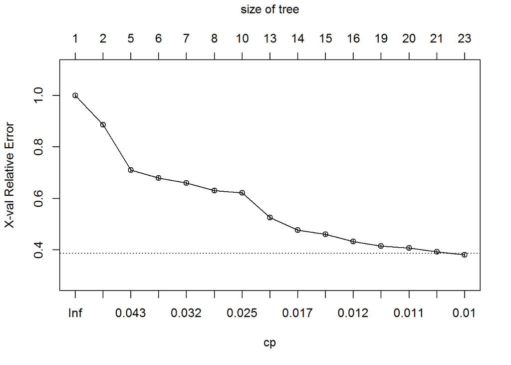

```r
plotcp(fit.rpart)
```

This plot shows that a tree of depth 23 was before the error rate was not improved by 0.01, the value of cp parameter. The error rate improved with every level, which I would guess I would expect.

This is supposed to do k-fold cross validation with 10 folds, by default. How do we know the accuracy or misclassification rate of this tree? It is not directly reported, but apparently we can compute it from the root error rate and the xerror for a level [I cannot figure out how to reference the values in the structure]:

```r
# cv misclassification = root node error * xerror for tree depth
# [how to get them from fit summary?]
# For row 15, 22 splits, ...
err <- 0.71540 * 0.38116
acc <- 1 - err
percent(c(acc, err))
```

```
## [1] "72.7%" "27.3%"
```

Let’s do a confusion matrix to get the error rate on the training set:

```r
rpart.predictions.train <- predict(fit.rpart, type = 'class')
rpart.cm.train <- confusionMatrix(data = rpart.predictions.train, reference = trainSet$classe)
rpart.cm.train
```

```
## Confusion Matrix and Statistics
##
##           Reference
## Prediction    A    B    C    D    E
##          A 3157  399   41  118   70
##          B  121 1594  254  195  261
##          C   62  155 1652  274  209
##          D  222  259  269 1298  158
##          E   45   44    0  192 1625
##
## Overall Statistics
##
##                Accuracy : 0.7358
##                  95% CI : (0.7281, 0.7435)
##     No Information Rate : 0.2846
##     P-Value [Acc > NIR] : < 2.2e-16
##
##                   Kappa : 0.6654
##  Mcnemar's Test P-Value : < 2.2e-16
##
## Statistics by Class:
##
##                      Class: A Class: B Class: C Class: D Class: E
## Sensitivity            0.8752   0.6503   0.7455   0.6249   0.6995
## Specificity            0.9307   0.9187   0.9331   0.9143   0.9729
## Pos Pred Value         0.8341   0.6573   0.7024   0.5884   0.8526
## Neg Pred Value         0.9494   0.9164   0.9454   0.9256   0.9352
## Prevalence             0.2846   0.1934   0.1748   0.1639   0.1833
## Detection Rate         0.2491   0.1258   0.1303   0.1024   0.1282
## Detection Prevalence   0.2986   0.1913   0.1856   0.1741   0.1504
## Balanced Accuracy      0.9030   0.7845   0.8393   0.7696   0.8362
```

This says the accuracy on the training set is 73.6%. Comparable to the the computed value above.

Apply to test set:

```r
rpart.predictions.test <- predict(fit.rpart, testSet, type = 'class')
rpart.cm.test <- confusionMatrix(data = rpart.predictions.test, reference = testSet$classe)
rpart.cm.test
```

```
## Confusion Matrix and Statistics
##
##           Reference
## Prediction    A    B    C    D    E
##          A 1624  220   34   41   43
##          B   71  796  139  129  154
##          C   39  105  849  159  115
##          D  133  140  141  660   69
##          E   30   29    0  104  845
##
## Overall Statistics
##
##                Accuracy : 0.7158
##                  95% CI : (0.7049, 0.7267)
##     No Information Rate : 0.2845
##     P-Value [Acc > NIR] : < 2.2e-16
##
##                   Kappa : 0.6403
##  Mcnemar's Test P-Value : < 2.2e-16
##
## Statistics by Class:
##
##                      Class: A Class: B Class: C Class: D Class: E
## Sensitivity            0.8561   0.6171   0.7300  0.60384   0.6892
## Specificity            0.9292   0.9083   0.9241  0.91338   0.9701
## Pos Pred Value         0.8277   0.6175   0.6701  0.57743   0.8383
## Neg Pred Value         0.9420   0.9082   0.9419  0.92164   0.9327
## Prevalence             0.2845   0.1934   0.1744  0.16389   0.1838
## Detection Rate         0.2435   0.1194   0.1273  0.09897   0.1267
## Detection Prevalence   0.2942   0.1933   0.1900  0.17139   0.1511
## Balanced Accuracy      0.8926   0.7627   0.8270  0.75861   0.8296
```

Accuracy on the test set is 71.6%.

Let’s move along.

#### Classification Tree: rpart via train() w/ varying cp

Let’s try a rpart classification tree calling via train(), rather than directly. The big difference here is train() will explore different values for cp, the complexity factor, whereas when we created via rpart(), cp was fixed at 0.01

Create model doing 10-fold cross-validation:

```r
trc <- trainControl(method = 'cv', number = 10)

rpart.model <- train(factor(classe) ~ .,
                     data = trainSet,
                     method    = "rpart",
                     trControl = trc)
rpart.model
```

```
## CART
##
## 12674 samples
##    52 predictor
##     5 classes: 'A', 'B', 'C', 'D', 'E'
##
## No pre-processing
## Resampling: Cross-Validated (10 fold)
##
## Summary of sample sizes: 11406, 11408, 11406, 11407, 11407, 11405, ...
##
## Resampling results across tuning parameters:
##
##   cp          Accuracy   Kappa       Accuracy SD  Kappa SD
##   0.03661630  0.5048127  0.35476737  0.02389481   0.03696012
##   0.05161575  0.4244742  0.22415159  0.06106527   0.10450946
##   0.11415022  0.3315418  0.07165618  0.04043528   0.06182992
##
## Accuracy was used to select the optimal model using  the largest value.
## The final value used for the model was cp = 0.0366163.
```

```r
rpart.model$finalModel
```

```
## n= 12674
##
## node), split, n, loss, yval, (yprob)
##       * denotes terminal node
##
##  1) root 12674 9067 A (0.28 0.19 0.17 0.16 0.18)
##    2) roll_belt< 130.5 11623 8024 A (0.31 0.21 0.19 0.18 0.11)
##      4) pitch_forearm< -26.65 1148   50 A (0.96 0.044 0 0 0) *
##      5) pitch_forearm>=-26.65 10475 7974 A (0.24 0.23 0.21 0.2 0.12)
##       10) roll_forearm< 123.5 6701 4435 A (0.34 0.24 0.16 0.19 0.071)
##         20) magnet_dumbbell_y< 437.5 5481 3269 A (0.4 0.18 0.18 0.17 0.062) *
##         21) magnet_dumbbell_y>=437.5 1220  593 B (0.044 0.51 0.026 0.31 0.11) *
##       11) roll_forearm>=123.5 3774 2603 C (0.062 0.2 0.31 0.21 0.21) *
##    3) roll_belt>=130.5 1051    8 E (0.0076 0 0 0 0.99) *
```

Figure out how to access cross-validated accuracy:

```r
#str(rpart.model)
df       <- rpart.model$results
bestcp   <- rpart.model$bestTune$cp
accuracy <- df[df$cp == bestcp,'Accuracy']
percent(accuracy)
```

```
## [1] "50.5%"
```

Just for grins, what was the accuracy is on the training data set:

```r
rpart.predictions.train <- predict(rpart.model)
rpart.cm.train          <- confusionMatrix(data = rpart.predictions.train, reference = trainSet$classe)
rpart.cm.train
```

```
## Confusion Matrix and Statistics
##
##           Reference
## Prediction    A    B    C    D    E
##          A 3310 1053 1013  912  341
##          B   54  627   32  374  133
##          C  235  771 1171  791  806
##          D    0    0    0    0    0
##          E    8    0    0    0 1043
##
## Overall Statistics
##
##                Accuracy : 0.4853
##                  95% CI : (0.4766, 0.4941)
##     No Information Rate : 0.2846
##     P-Value [Acc > NIR] : < 2.2e-16
##
##                   Kappa : 0.3275
##  Mcnemar's Test P-Value : NA
##
## Statistics by Class:
##
##                      Class: A Class: B Class: C Class: D Class: E
## Sensitivity            0.9177  0.25581  0.52843   0.0000  0.44899
## Specificity            0.6339  0.94199  0.75110   1.0000  0.99923
## Pos Pred Value         0.4993  0.51393  0.31028      NaN  0.99239
## Neg Pred Value         0.9509  0.84075  0.88258   0.8361  0.88987
## Prevalence             0.2846  0.19339  0.17485   0.1639  0.18329
## Detection Rate         0.2612  0.04947  0.09239   0.0000  0.08229
## Detection Prevalence   0.5230  0.09626  0.29777   0.0000  0.08293
## Balanced Accuracy      0.7758  0.59890  0.63976   0.5000  0.72411
```

What is the accuracy on the test set:

```r
rpart.predictions.test <- predict(rpart.model, testSet)
rpart.cm.test          <- confusionMatrix(data = rpart.predictions.test, reference = testSet$classe)
rpart.cm.test
```

```
## Confusion Matrix and Statistics
##
##           Reference
## Prediction    A    B    C    D    E
##          A 1718  561  548  508  175
##          B   31  318   22  170   73
##          C  142  411  593  415  422
##          D    0    0    0    0    0
##          E    6    0    0    0  556
##
## Overall Statistics
##
##                Accuracy : 0.4776
##                  95% CI : (0.4655, 0.4897)
##     No Information Rate : 0.2845
##     P-Value [Acc > NIR] : < 2.2e-16
##
##                   Kappa : 0.3172
##  Mcnemar's Test P-Value : NA
##
## Statistics by Class:
##
##                      Class: A Class: B Class: C Class: D Class: E
## Sensitivity            0.9056  0.24651  0.50989   0.0000  0.45351
## Specificity            0.6245  0.94497  0.74755   1.0000  0.99890
## Pos Pred Value         0.4895  0.51792  0.29904      NaN  0.98932
## Neg Pred Value         0.9433  0.83947  0.87836   0.8361  0.89029
## Prevalence             0.2845  0.19343  0.17439   0.1639  0.18384
## Detection Rate         0.2576  0.04768  0.08892   0.0000  0.08337
## Detection Prevalence   0.5263  0.09207  0.29735   0.0000  0.08427
## Balanced Accuracy      0.7651  0.59574  0.62872   0.5000  0.72620
```

Accuracy on the test set is 47.8%.

#### Classification Tree: rpart via train() w/ fixed cp = 0.01

Let’s try fixing cp = 0.01 and see if we can recreate the rpart() model:

```r
trc <- trainControl(method = 'cv', number = 10)
rpg <- rpart.grid <- expand.grid(cp = c(0.01))

rpart.model <- train(factor(classe) ~ .,
                     data = trainSet,
                     method    = "rpart",
                     trControl = trc,
                     tuneGrid  = rpg)
rpart.model
```

```
## CART
##
## 12674 samples
##    52 predictor
##     5 classes: 'A', 'B', 'C', 'D', 'E'
##
## No pre-processing
## Resampling: Cross-Validated (10 fold)
##
## Summary of sample sizes: 11406, 11407, 11407, 11406, 11406, 11405, ...
##
## Resampling results
##
##   Accuracy   Kappa      Accuracy SD  Kappa SD
##   0.7236094  0.6489873  0.01767691   0.02166229
##
## Tuning parameter 'cp' was held constant at a value of 0.01
##
```

Ah, now we get an cv accuracy of 72.4% which is comparable to the rpart() model.

TODO:  
- So, how does train() chose the range of values for cp to explore?  
- Should we use default values chosed by train() or specify our own?

#### Classification Tree: tree()

Let’s call tree() directly and see if we get anything different from rpart():

```r
tree.model <- tree(factor(classe) ~ ., data=trainSet)
tree.model.summary <- summary(tree.model)
tree.model.summary
```

```
##
## Classification tree:
## tree(formula = factor(classe) ~ ., data = trainSet)
## Variables actually used in tree construction:
##  [1] "roll_belt"         "pitch_forearm"     "roll_forearm"
##  [4] "magnet_dumbbell_x" "yaw_belt"          "magnet_dumbbell_y"
##  [7] "pitch_belt"        "yaw_dumbbell"      "roll_dumbbell"
## [10] "yaw_arm"           "magnet_dumbbell_z" "accel_forearm_x"
## Number of terminal nodes:  18
## Residual mean deviance:  1.633 = 20670 / 12660
## Misclassification error rate: 0.3242 = 4109 / 12674
```

Creates a tree from 12 attributes having 18 leaf nodes and has a misclassification error rate on the training set of 0.3242.

The accuracy on the training set was 67.6%.

Let’s look at the tree:

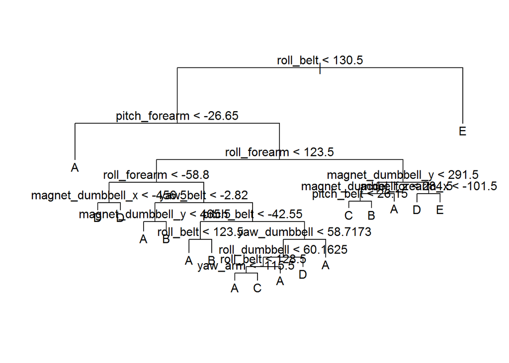

```r
plot(tree.model); text(tree.model)
```

Kinda ugly. [Is the entire tree really shown, or is it pruned for display?]

Let’s cross-validate (using 10 folds) using misclass and deviance as measures and see if we should prune the tree:

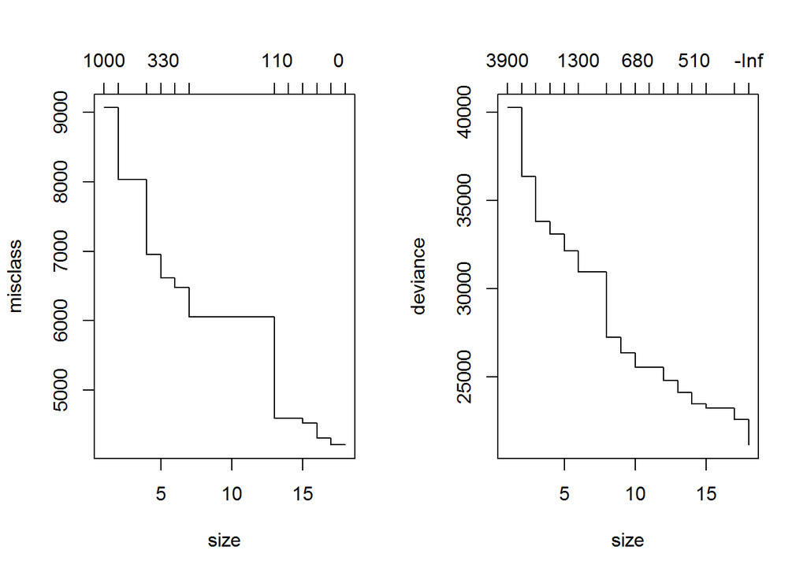

```r
misclass.cv.tree.model <- cv.tree(tree.model, FUN = prune.tree, method = "misclass")
dev.cv.tree.model      <- cv.tree(tree.model)

par(mfrow=c(1,2))
plot(misclass.cv.tree.model)
plot(dev.cv.tree.model)
```

```r
par(mfrow=c(1,1))
```

Both graphs continue decreasing, suggesting that all nodes are needed. Leave the tree as it is; do not prune it.

But what is the cross-validated accuracy/error? Where is it reported?

```r
# I cannot find out how to compute the cross-validated error rate
# Not clear that it's really a cross-validation
```

Let’s see how well it predicts on the test data [seems like this should be part of the tree result]:

```r
tree.predictions.test <- predict(tree.model, testSet, type = 'class')
tree.cm.test <- confusionMatrix(data = tree.predictions.test, reference = testSet$classe)
tree.cm.test
```

```
## Confusion Matrix and Statistics
##
##           Reference
## Prediction    A    B    C    D    E
##          A 1630  269   14   26   48
##          B   33  441   39   11    8
##          C   27   87  882  275  111
##          D  175  267  135  705  258
##          E   32  226   93   76  801
##
## Overall Statistics
##
##                Accuracy : 0.6686
##                  95% CI : (0.6572, 0.6799)
##     No Information Rate : 0.2845
##     P-Value [Acc > NIR] : < 2.2e-16
##
##                   Kappa : 0.5816
##  Mcnemar's Test P-Value : < 2.2e-16
##
## Statistics by Class:
##
##                      Class: A Class: B Class: C Class: D Class: E
## Sensitivity            0.8593  0.34186   0.7584   0.6450   0.6533
## Specificity            0.9252  0.98308   0.9092   0.8503   0.9216
## Pos Pred Value         0.8203  0.82895   0.6382   0.4578   0.6523
## Neg Pred Value         0.9430  0.86166   0.9469   0.9244   0.9219
## Prevalence             0.2845  0.19343   0.1744   0.1639   0.1838
## Detection Rate         0.2444  0.06613   0.1323   0.1057   0.1201
## Detection Prevalence   0.2979  0.07977   0.2072   0.2309   0.1841
## Balanced Accuracy      0.8922  0.66247   0.8338   0.7476   0.7874
```

Accuracy on test set is 66.9%. About like an rpart tree with cp=0.01.

So a single tree isn’t enough. Let’s try a forest of trees ;-)

#### Random Forest: randomForest()

Some notes on Random Forest from [Random Forests] (http://www.stat.berkeley.edu/~breiman/RandomForests/cc_home.htm#overview) by Leo Breiman and Adele Cutler:  
- Random forests does not overfit.  
- There is no need for cross-validation or a separate test set to get an unbiased estimate of the test set error. It is estimated internally, during the run.

Since we do not need to need to cross-validate, we will not use the caret train() function which does cross-validation by default. We will create the forest by calling randomForest() directly.

Link to documentation: [Package ‘randomForest’](https://cran.r-project.org/web/packages/randomForest/randomForest.pdf)

```r
rf.model <- randomForest(factor(classe) ~ ., data = trainSet)
print(rf.model)
```

```
##
## Call:
##  randomForest(formula = factor(classe) ~ ., data = trainSet)
##                Type of random forest: classification
##                      Number of trees: 500
## No. of variables tried at each split: 7
##
##         OOB estimate of  error rate: 0.52%
## Confusion matrix:
##      A    B    C    D    E class.error
## A 3600    4    1    1    1 0.001940671
## B    9 2438    4    0    0 0.005303958
## C    1   12 2200    3    0 0.007220217
## D    0    0   22 2053    2 0.011555128
## E    0    0    1    5 2317 0.002582867
```

Figure out how to access the error rate:

```r
str(rf.model)
```

[output not shown]

[output cut: 61 more lines]

[output not shown]

```r
error <- rf.model$err.rate[rf.model$ntree]
accuracy <- 1 - error
percent(c(accuracy, error))
```

```
## [1] "99.5%" "0.5%"
```

The OOB estimate of error rate is 0.521%. The estimate of accuracy is 99.5%.

Plot error rate vs number of trees:

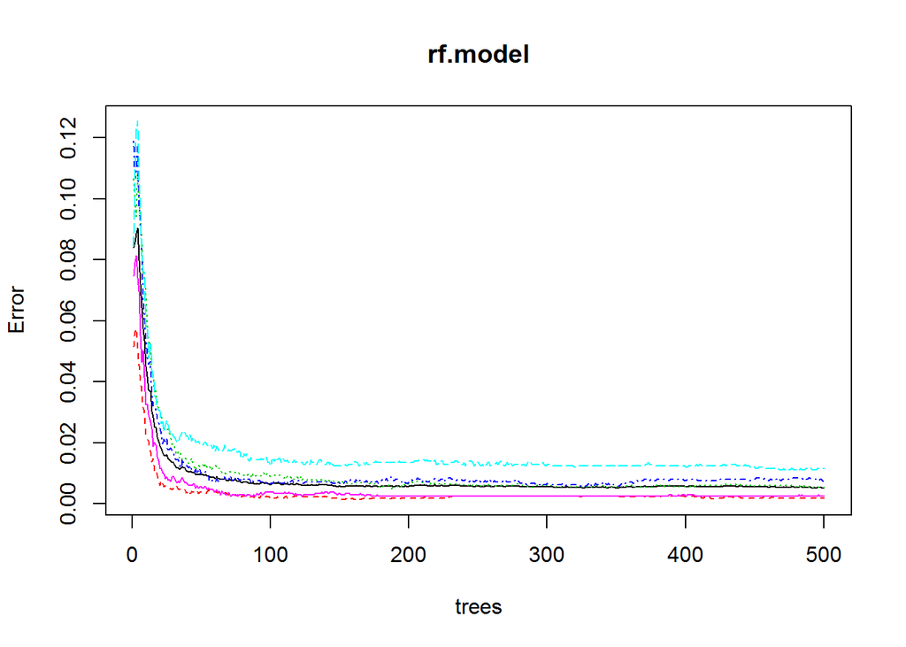

```r
plot(rf.model)
```

Seems like we have pretty good error rate with as little as 100 trees. We could specify something less than the default 500 trees if performance were a concern.

Verify error rate on training set:

```r
rf.predictions <- predict(rf.model)
rf.cm <- confusionMatrix(data = rf.predictions, reference = trainSet$classe)
rf.cm
```

```
## Confusion Matrix and Statistics
##
##           Reference
## Prediction    A    B    C    D    E
##          A 3600    9    1    0    0
##          B    4 2438   12    0    0
##          C    1    4 2200   22    1
##          D    1    0    3 2053    5
##          E    1    0    0    2 2317
##
## Overall Statistics
##
##                Accuracy : 0.9948
##                  95% CI : (0.9934, 0.996)
##     No Information Rate : 0.2846
##     P-Value [Acc > NIR] : < 2.2e-16
##
##                   Kappa : 0.9934
##  Mcnemar's Test P-Value : NA
##
## Statistics by Class:
##
##                      Class: A Class: B Class: C Class: D Class: E
## Sensitivity            0.9981   0.9947   0.9928   0.9884   0.9974
## Specificity            0.9989   0.9984   0.9973   0.9992   0.9997
## Pos Pred Value         0.9972   0.9935   0.9874   0.9956   0.9987
## Neg Pred Value         0.9992   0.9987   0.9985   0.9977   0.9994
## Prevalence             0.2846   0.1934   0.1748   0.1639   0.1833
## Detection Rate         0.2840   0.1924   0.1736   0.1620   0.1828
## Detection Prevalence   0.2848   0.1936   0.1758   0.1627   0.1831
## Balanced Accuracy      0.9985   0.9966   0.9951   0.9938   0.9986
```

Apply to test set:

```r
rf.predictions.test <- predict(rf.model, testSet)
rf.cm <- confusionMatrix(data = rf.predictions.test, reference = testSet$classe)
rf.cm
```

```
## Confusion Matrix and Statistics
##
##           Reference
## Prediction    A    B    C    D    E
##          A 1895    5    0    0    0
##          B    1 1276    7    0    0
##          C    0    9 1154    9    1
##          D    0    0    2 1084    5
##          E    1    0    0    0 1220
##
## Overall Statistics
##
##                Accuracy : 0.994
##                  95% CI : (0.9918, 0.9957)
##     No Information Rate : 0.2845
##     P-Value [Acc > NIR] : < 2.2e-16
##
##                   Kappa : 0.9924
##  Mcnemar's Test P-Value : NA
##
## Statistics by Class:
##
##                      Class: A Class: B Class: C Class: D Class: E
## Sensitivity            0.9989   0.9891   0.9923   0.9918   0.9951
## Specificity            0.9990   0.9985   0.9965   0.9987   0.9998
## Pos Pred Value         0.9974   0.9938   0.9838   0.9936   0.9992
## Neg Pred Value         0.9996   0.9974   0.9984   0.9984   0.9989
## Prevalence             0.2845   0.1934   0.1744   0.1639   0.1838
## Detection Rate         0.2842   0.1913   0.1730   0.1625   0.1829
## Detection Prevalence   0.2849   0.1925   0.1759   0.1636   0.1831
## Balanced Accuracy      0.9989   0.9938   0.9944   0.9953   0.9975
```

Looks like a random forest will be sufficient for this data set.

#### Random Forest: randomForest() w/150 trees

Let’s see what accuracy we get by reduing the number of trees.

```r
rf.150.model <- randomForest(factor(classe) ~ ., data = trainSet, ntree = 150)
print(rf.150.model)
```

```
##
## Call:
##  randomForest(formula = factor(classe) ~ ., data = trainSet, ntree = 150)
##                Type of random forest: classification
##                      Number of trees: 150
## No. of variables tried at each split: 7
##
##         OOB estimate of  error rate: 0.57%
## Confusion matrix:
##      A    B    C    D    E class.error
## A 3602    3    1    1    0 0.001386194
## B   11 2434    6    0    0 0.006935945
## C    0   14 2199    3    0 0.007671480
## D    0    0   22 2052    3 0.012036591
## E    0    1    1    6 2315 0.003443823
```

[output not shown]

The OOB estimate of error rate is 0.568%. The estimate of accuracy is 99.4%. Essentially the same as with 500 trees.

Let use train() with 10-fold cross-validation and see what we get for a random forest. To control run time, use the randomForest() default value for mtry, which for classification models is the square root of the number of predictors:

```r
rf.train.trc   <- trainControl(method = 'cv', number = 10)

rf.train.grid  <- expand.grid(mtry=c(floor(sqrt(ncol(trainSet)))))

rf.train.model <- train(factor(classe) ~ .,
                        data      = trainSet,
                        method    = "rf",
                        trControl = rf.train.trc,
                        ntree     = 101,
                        tuneGrid  = rf.train.grid)
rf.train.model
```

```
## Random Forest
##
## 12674 samples
##    52 predictor
##     5 classes: 'A', 'B', 'C', 'D', 'E'
##
## No pre-processing
## Resampling: Cross-Validated (10 fold)
##
## Summary of sample sizes: 11407, 11407, 11406, 11408, 11406, 11407, ...
##
## Resampling results
##
##   Accuracy   Kappa      Accuracy SD  Kappa SD
##   0.9923462  0.9903171  0.002785432  0.00352405
##
## Tuning parameter 'mtry' was held constant at a value of 7
##
```

```r
rf.train.model$finalModel
```

```
##
## Call:
##  randomForest(x = x, y = y, ntree = 101, mtry = param$mtry)
##                Type of random forest: classification
##                      Number of trees: 101
## No. of variables tried at each split: 7
##
##         OOB estimate of  error rate: 0.72%
## Confusion matrix:
##      A    B    C    D    E class.error
## A 3599    3    3    1    1 0.002217910
## B    8 2431   12    0    0 0.008159935
## C    0   19 2192    5    0 0.010830325
## D    1    0   27 2047    2 0.014443909
## E    0    0    4    5 2314 0.003874300
```

[output not shown]

The OOB estimate of error rate is 0.718%. The estimate of accuracy is 99.3%. About the same as a randomForest() without explicit cross-validation.

### Stop Cluster

Turn off parallelism:

```r
stopCluster(r.cluster)
```